# Introduction to Spline-DV

Shreyan Gupta, James J Cai

Abstract

This tutorial shows how to use **Spline-DV** for Differential Variability Analysis across two single-cell RNA seq samples and **Spline-HVG** for highly variable feature selection

# Why to use SplineDV?

## Beyond Averages

One of the most intuitive ways to evaluate a gene expression change is using Differential Expression (DE) analysis. Traditionally, DE analysis focuses on identifying genes that are up- or down-regulated (increased or decreased expression) between conditions, typically employing a basic mean-difference approach. We propose a paradigm shift that acknowledges the central role of gene expression variability in cellular function and challenges the current dominance of mean-based DE analysis in single-cell studies. We suggest that scRNA-seq data analysis should embrace the role of inherent gene expression variability in defining cellular function and move beyond mean-based approaches.

# Overview of the SplineDV workflow

## Input - Two expression matrix

The expression matrix should be formatted with the genes/features as rows and cells as columns. Ideally, the matrix will be stored in sparse format to save memory.

The two input matrices must be stored in two separate expression matrices or Seurat objects.

```r
# i.e. Reading a Seurat RDS file
exprMatrix <- readRDS('mySingleCellExperiment.rds')

# or .h5 file experiment
exprMatrix <- Seurat::Read10X_h5('mySingleCellExperiment.h5')
```

Loading two separate expression matrices

```r
# i.e. Reading a Seurat RDS file
exprMatrix_1 <- readRDS('mySingleCellExperiment_1.rds')
exprMatrix_2 <- readRDS('mySingleCellExperiment_2.rds')

# or .h5 file experiment
exprMatrix_1 <- Seurat::Read10X_h5('mySingleCellExperiment_1.h5')
exprMatrix_2 <- Seurat::Read10X_h5('mySingleCellExperiment_2.h5')
```

## Loading scRNAseq count example data

The example data is borrowed from an experimental *Nkx2-1* Gene knockout scRNA-seq study by Liebler *et al.* <sup>1</sup>

```r
# Load Data
exprMatrix_WT = read.csv('../data/WTdata.csv', row.names = 1) # WT Sample
exprMatrix_KO = read.csv('../data/KOdata.csv', row.names = 1) # KO Sample

# Convert to Seurat Object
SeuratObj_WT <- CreateSeuratObject(CreateAssayObject(exprMatrix_WT))
SeuratObj_WT
```

```
An object of class Seurat
5000 features across 540 samples within 1 assay
Active assay: RNA (5000 features, 0 variable features)
 2 layers present: counts, data
```

```r
SeuratObj_KO <- CreateSeuratObject(CreateAssayObject(exprMatrix_KO))
SeuratObj_KO
```

```
An object of class Seurat
5000 features across 481 samples within 1 assay
Active assay: RNA (5000 features, 0 variable features)
 2 layers present: counts, data
```

## Running Spline-DV

For the analysis, the test data (X) is always use in contrast with the control data (Y).

```r
library(SplineDV)
DV_res = DV_splinefit(X = exprMatrix_KO, Y = exprMatrix_WT)
```

|  | genes | mu1 | mu2 | CV1 | CV2 | drop1 | drop2 | dist1 | dist2 | Spline_Dist | Direction | Pval |
| --- | --- | --- | --- | --- | --- | --- | --- | --- | --- | --- | --- | --- |
| 1 | Ager | 0.16044058 | 0.9556459 | 2.216996 | 1.774189 | 0.9209979 | 0.6375321 | 0.1178799 | 0.9236846 | 1.865361 | -1 | 1.121028e-77 |
| 2 | Mgp | 1.05771041 | 1.2199219 | 2.025285 | 1.773167 | 0.8627859 | 0.7840617 | 1.0170386 | 1.1047567 | 1.838660 | -1 | 6.729178e-73 |
| 3 | S100a6 | 0.86146941 | 0.5983844 | 1.320465 | 1.878510 | 0.4719335 | 0.7634961 | 0.5237322 | 0.5876942 | 1.665917 | -1 | 1.016197e-45 |
| 4 | Sftpa1 | 0.04157808 | 0.5312101 | 1.911414 | 1.687157 | 0.9646570 | 0.6503856 | 0.0000000 | 0.5226164 | 1.527323 | -1 | 1.388362e-28 |
| 5 | Sftpc | 0.81457294 | 2.7561787 | 1.617910 | 1.417244 | 0.4116424 | 0.0000000 | 0.7863505 | 0.0000000 | 1.499756 | 1 | 1.137645e-25 |
| 6 | Hspa1a | 0.38376462 | 1.2905855 | 1.583461 | 1.143814 | 0.8648649 | 0.6401028 | 0.2896317 | 0.5566712 | 1.482690 | -1 | 5.992020e-24 |

## Visualize Gene Expression distributions

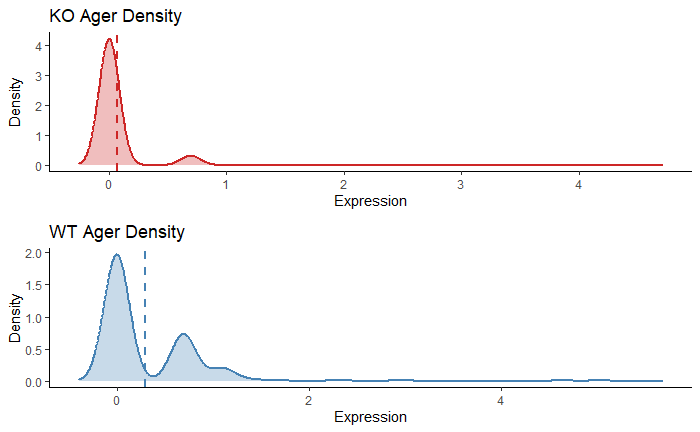

```r
library(MASS)
library(scales)
library(ggplot2)
library(ggpubr)

getdensity <- function(data, gene, col = 'firebrick3',
                       ident = NULL, plot.mu = F){

  dat = log(as.numeric(data[gene,])+1) # Log1p transforming
  dat.line = density(dat)

  df = data.frame(x = dat.line$x, y = dat.line$y, Genotype = ident)
  p1 = ggplot(df, aes(x = x, y = y))+ theme_classic() +
    geom_area(aes(x = x, y = y), color = col,
              fill = alpha(col,0.3), linewidth = 1) +
    labs(x = 'Expression',y = 'Density') +
    ggtitle(paste0(ident,' ',gene, ' Density'))
  if (is.null(legend) == F){
    p1 = p1
    p1
  }
  if (plot.mu == T){
    p1 = p1 + geom_vline(xintercept = log(mean(dat)+1),
                         col = col, lty = 'dashed', linewidth = 1)
  }
  return(p1)
}

gene = 'Ager'
p1 = getdensity(exprMatrix_KO, gene = gene, ident = 'KO', plot.mu = T)
p2 = getdensity(exprMatrix_WT, gene = gene, col = 'steelblue', ident = 'WT', plot.mu = T)
ggarrange(p1,p2,ncol = 1, align = 'hv')
```

# Highly Variable Genes (HVGs) using Spline-HVG

## Input - scRNA-seq Expression matrix

```r
library(Seurat,verbose = F)

# Loading Data
exprMatrix = read.csv('../data/WTdata.csv', row.names = 1) # WT Sample
```

## Running Spline-HVG

```r
HVG_res = HVG_splinefit(exprMatrix, nHVGs = 100)
```

```r
head(HVG_res)
```

[output not shown]

```r
# Extracting HVG Gene list
HVG_list = rownames(HVG_res)[HVG_res$HVG == TRUE]
HVG_list
```

[output not shown]

# Appendix

## References

1. Liebler JM, Marconett CN, Juul N, et al. Combinations of differentiation markers distinguish subpopulations of alveolar epithelial cells in adult lung. Am J Physiol Lung Cell Mol Physiol. 2016;310(2):L114-L120. doi:10.1152/ajplung.00337.2015

# sessionInfo

```r
date()
sessionInfo()
```

[output not shown]